# DATA 550 Lab 3 - Communication visualizations

There are two versions of this lab, one in Python and one in R. The R lab will use `ggplot` and the Python lab will use `Altair`.

This is the R version.

Each partner should choose a version to complete, though keep in mind that **you are required to alternate between completing the R labs and the Python labs** to get experience using both languages.

## Acknowledgemnts

This lab was lightly adapted from the one created by Joel Ostblom for the DSCI 531 version of Data Viz I in the 2020/21 Academic year.

## Submission instructions

rubric={mechanics:2}

You receive marks for submitting your lab correctly, please follow these instructions:

- Create a GitHub Repo for your group.
  - Keep this organized, i.e. with a separate clearly marked folder for each assignment.
- [Click here to view a description of the rubrics used to grade the questions](https://github.com/UBC-MDS/public/tree/master/rubric)
- Push your `.ipynb` file to your GitHub repository for this lab.
- Include a clickable link to your GitHub repo for the lab just below this cell
  - It should look something like this https://github.ubc.ca/folder_path/DATA_550_labX_groupY.
- Upload a `.html` version of your assignment to Canvas.
  - Run all cells in your notebook to make sure there are no errors by doing `Kernel -> Restart Kernel and Run All Cells...`
  - Convert your notebook to .html format using `File -> Save and Export Notebook As -> HTML`
  - Submit and double check that your have submitted the correct file to Canvas

### GITHUB LINK:

https://github.com/Christian-Ji/data_550_Dataviz_1.git

## 0. So we meet again...

I am sure you have heard, turns out Bestflix did not make it. Copyright issues they said, can you believe it?? I can't, there must have been more to this story... And the only other person with knowledge of this enterprise was... YOU!

In the spirit of a true comic book criminal, I will scale my revenge for this set back completely out of proportion and attempt world dominion. Don't worry, there will be no blood shed, I operate with class so my plan here is to brainwash people into thinking that I am actually good for them and then reap personal benefits once in power, creative isn't it?

To convince the pleb... I mean honorary citizens of the world to vote for me, I have made several key visualizations showing what an ideal candidate I am. The only way to stop me (hmm why am I telling you this again...) is to debunk these visualizations and show voters the errors of my ways (this is clearly a fictional scenario since we are assuming that each person acts rationally and is convinced by data).

Below is my publicly distributed campaign material covering these four main area:

1. The current dramatic increase in job dissatisfaction
2. My previous record on increasing job wages for all
3. Guns to the people
4. My great approval rating

For each figure that I have made, I have also included the underlying data (imagine what a wonderful world it would be if that actually happened in real life...). You can find these datasets in your lab repo). For each question in this lab, your team has the following three tasks:

1. Decide if you think my plot and my claim is misleading or not, why you think so, and how you would improve it in your version of the same figure (unless you think mine is already good). In addition to what we are learning this week, you will need to draw on your knowledge from last week for when certain plots are suitable and which are common pitfalls to avoid.
2. To earn the people's trust, you need to recreate my plot to show that you know what I did. This includes axis labels, legends, colors, titles, figure size, everything as close as possible to the images I have pasted for each question below.
3. Create your own better version of the same figure. Make sure that your choices are motivated in writing in point 1.

# 1. Dramatic decline in job satisfaction

## The data

The `cities-job-satisfaction.csv` dataset contains (fictional) data from different cities around the world. In this data it was measured which proportion of people reported that they were unsatisfied with their work situation this year compared to last year. Each data point is a different city, and the value indicates the proportion of dissatisfied workers.

## My claim

You can clearly see in this plot that people are dramatically more dissatisfied at work this year compared to last year. I have used transparency for the dots to prevent overplotting/oversaturation, so this means that the entire dark area has an even amount of cities throughout. In other words, there are as many cities that increased from ~0% to ~40% dissatisfaction as there are cities that stayed around 0%. That's atrocious!

### Question 1.1

rubric={reasoning:2,writing:1}

- Explain which mistakes (if any) I have done in my plot and provide an interpretation of the data that is more correct than mine. Be brief and clear in your answer.
- You might have some ideas just from looking at my plot, but you will likely need to do some investigation yourself to answer this question fully. You can reference your improved plot as needed.

The plot is misleading because heavy overplotting plus transparency creates a very dark “blob,” but darkness does not mean the points are evenly distributed across that region. The darkness mainly shows that many cities are concentrated near low last_year dissatisfaction, not that “all changes are equally common.” Also, interpreting an increase requires comparing to the y = x line (no change). From the scatter, most cities appear to have similar or slightly higher dissatisfaction this year, but the biggest pattern is that many cities were already low last year and remain relatively low, with a smaller number showing larger increases.

### Question 1.2

rubric={accuracy:2}

#### R

Recreate my ggplot version of the plot. Your plot should look as close as possible to mine in the image above.

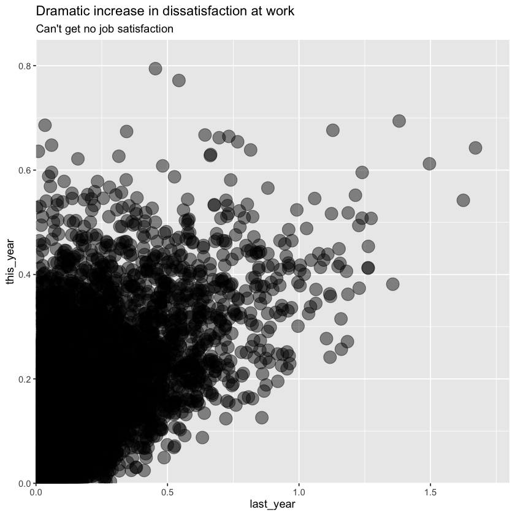

```r
# YOUR ANSWER HERE
library(readr)
library(ggplot2)

df <- read_csv("data/cities-job-satisfaction.csv", show_col_types = FALSE)

ggplot(df, aes(x = last_year, y = this_year)) +
  geom_point(color = "black", alpha = 0.45, size = 5.5) +
  labs(
    title = "Dramatic increase in dissatisfaction at work",
    subtitle = "Can't get no job satisfaction",
    x = "last_year",
    y = "this_year"
  ) +
  scale_x_continuous(limits = c(0, 1.8), expand = c(0, 0)) +
  scale_y_continuous(limits = c(0, 0.85), expand = c(0, 0)) +
  theme_grey()
```

### Question 1.3

rubric={viz:2}

#### R

Improve my ggplot plot. Chose the best type of plot to accurately reveal what the data looks like. Design the plot to be an effective plot for communication purposes, this includes proper figure size, axis/figure titles, font sizes, colors, etc.

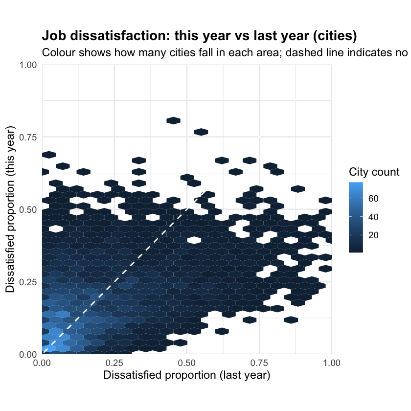

```r
# YOUR ANSWER HERE
library(readr)
library(ggplot2)

df <- read_csv("data/cities-job-satisfaction.csv", show_col_types = FALSE)

# If hexbin is not installed yet, run:
# install.packages("hexbin")
library(hexbin)

ggplot(df, aes(x = last_year, y = this_year)) +
  # Use hex bins to show density (fix overplotting)
  geom_hex(bins = 35) +
  # Reference line: no change (this_year = last_year)
  geom_abline(slope = 1, intercept = 0, linetype = "dashed", linewidth = 0.8, color = "white") +
  coord_fixed(xlim = c(0, 1), ylim = c(0, 1), expand = FALSE) +
  labs(
    title = "Job dissatisfaction: this year vs last year (cities)",
    subtitle = "Colour shows how many cities fall in each area; dashed line indicates no change (y = x)",
    x = "Dissatisfied proportion (last year)",
    y = "Dissatisfied proportion (this year)",
    fill = "City count"
  ) +
  theme_minimal(base_size = 14) +
  theme(
    plot.title = element_text(face = "bold"),
    legend.position = "right"
  )
```

# 2. I will keep raising wages for all

## The data

The `wages.csv` dataset contains (fictional) data from different companies in the city where I have been the mayor for the last few years. Each datapoint represents the average salary at a company. All the major companies in this city were surveyed both before I was elected and after a few years of my governing. However, this is not paired data, some companies are different from "before" and "after", so you do not need to do a paired analysis.

## My claim

As you can see, I have been able to produce a significant increase in the average salary for workers in my city. This high raise almost certainly entails that all (or almost all) workers are receiving a higher payment than what they were before I started to govern. But since I know you are going to ask me for more robust estimates, I have also provided the median increase (which is even more notable) and the number of workers in each group (so that you can see that the samples are balanced).

### Question 2.1

rubric={reasoning:2,writing:1}

- Explain which mistakes (if any) I have done in my plot and provide an interpretation of the data that is more correct than mine. Be brief and clear in your answer.
- You might have some ideas just from looking at my plot, but you will likely need to do some investigation yourself to answer this question fully. You can reference your improved plot as needed.

These plots are misleading because they only show group summaries (mean/median) and hide the full distributions. A higher mean/median “after” does not prove that (almost) everyone earns more, since outliers or a few high-salary companies can raise the average while many companies stay the same or drop. Also, the data are not paired, so we cannot claim the same companies increased. A more correct interpretation is: salaries are generally higher on average after, but we cannot conclude that nearly all workers benefited without showing the distributions and overlap.

### Question 2.2

rubric={accuracy:2}

#### R

Recreate my ggplot version of the plot. Your plot should look as close as possible to mine in the image above.

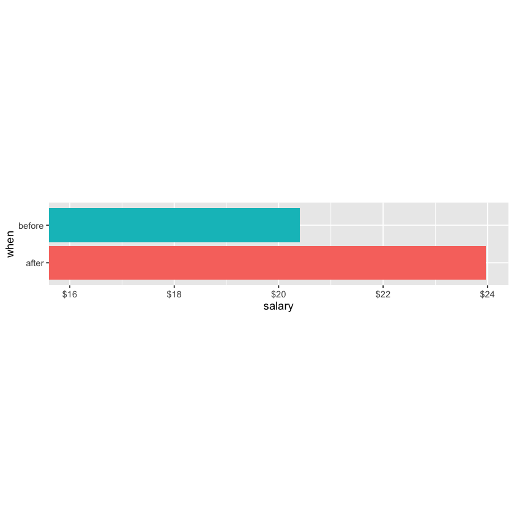

```r
# YOUR ANSWER HERE
library(readr)
library(dplyr)
library(ggplot2)
library(scales)

wages <- read_csv("data/wages.csv", show_col_types = FALSE)

mean_df <- wages %>%
  group_by(when) %>%
  summarise(value = mean(salary), .groups = "drop")

ggplot(mean_df, aes(x = value, y = when, fill = when)) +
  geom_col() +
  labs(x = "salary", y = "when") +
  scale_x_continuous(labels = dollar_format(prefix = "$")) +
  coord_cartesian(xlim = c(16, 24)) +
  theme_grey() +
  theme(
    legend.position = "none",
    aspect.ratio = 0.18
  )
```

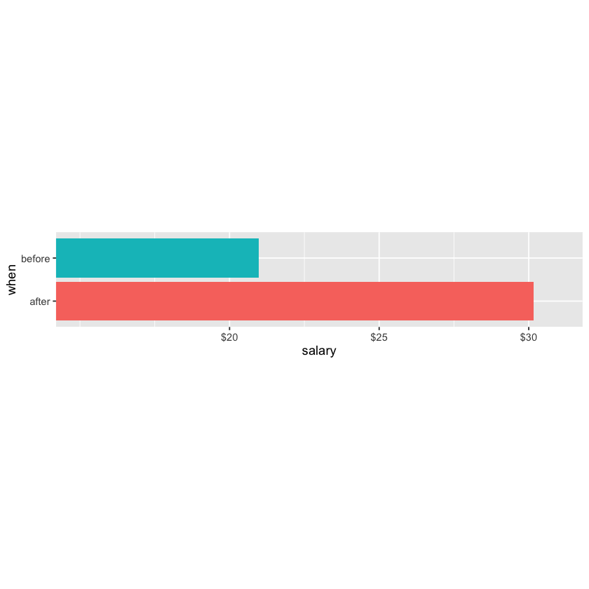

```r
# YOUR ANSWER HERE
library(readr)
library(dplyr)
library(ggplot2)
library(scales)

wages <- read_csv("data/wages.csv", show_col_types = FALSE)

wages <- wages %>%
  mutate(when = factor(when, levels = c("after", "before")))

med_df <- wages %>%
  group_by(when) %>%
  summarise(salary_med = median(salary, na.rm = TRUE), .groups = "drop")

ggplot(med_df, aes(x = salary_med, y = when, fill = when)) +
  geom_col(width = 0.9) +
  labs(x = "salary", y = "when") +
  scale_x_continuous(
    breaks = c(20, 25, 30),
    labels = dollar_format(prefix = "$")
  ) +
  coord_cartesian(xlim = c(15, 31)) +
  theme_grey() +
  theme(
    legend.position = "none",
    aspect.ratio = 0.18
  )
```

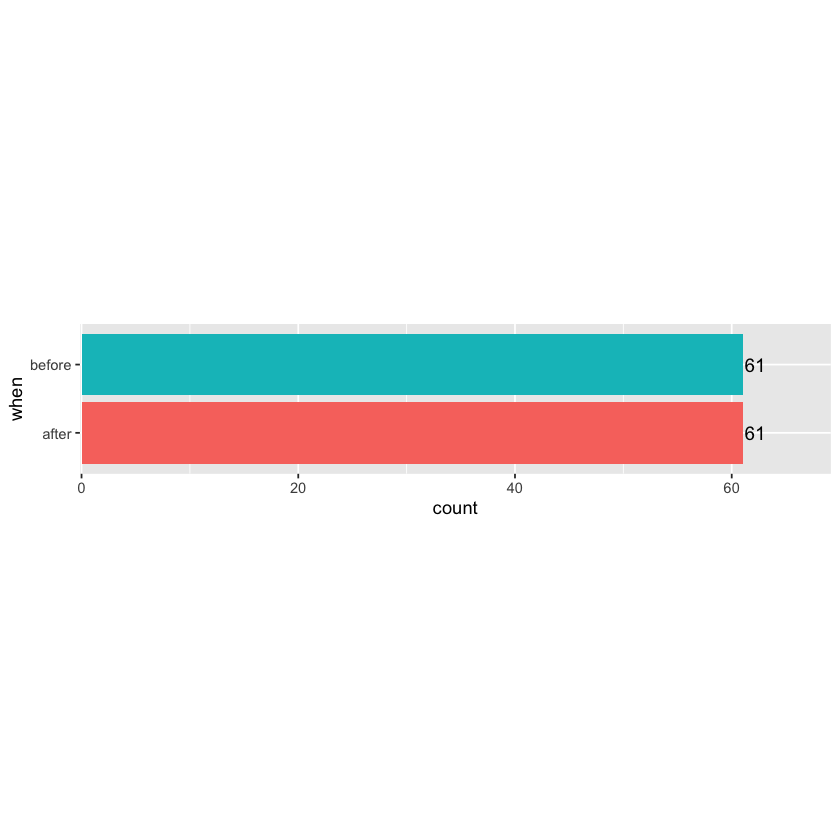

```r
# YOUR ANSWER HERE
library(readr)
library(dplyr)
library(ggplot2)

wages <- read_csv("data/wages.csv", show_col_types = FALSE)

n_df <- wages %>%
  count(when, name = "value")

ggplot(n_df, aes(x = value, y = when, fill = when)) +
  geom_col() +
  geom_text(aes(label = value), hjust = -0.1, size = 4) +
  labs(x = "count", y = "when") +
  coord_cartesian(xlim = c(3, max(n_df$value) + 5)) +
  theme_grey() +
  theme(
    legend.position = "none",
    aspect.ratio = 0.2
  )
```

### Question 2.3

rubric={viz:2}

#### R

Improve my ggplot plot. Chose the best type of plot to accurately reveal what the data looks like. Design the plot to be an effective plot for communication purposes, this includes proper figure size, axis/figure titles, font sizes, colors, etc. You can either make a single or several plots, depending on what you think is needed.

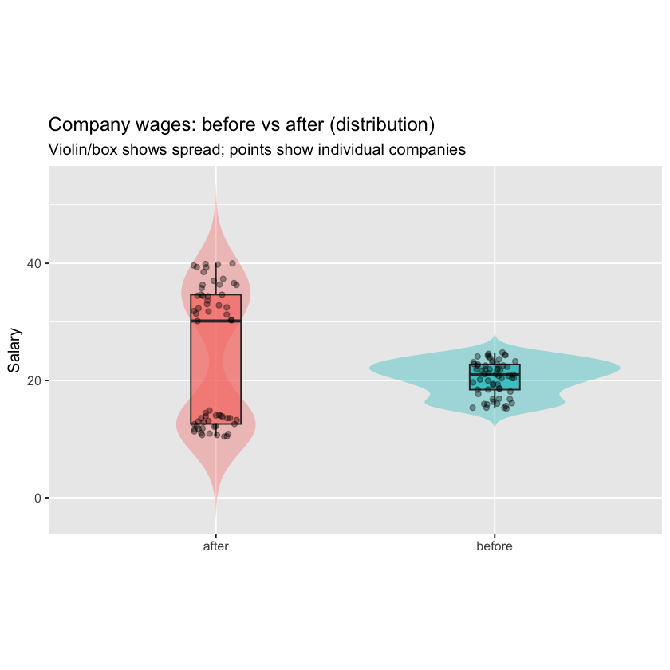

```r
# YOUR ANSWER HERE
library(readr)
library(ggplot2)

wages <- read_csv("data/wages.csv", show_col_types = FALSE)

ggplot(wages, aes(x = when, y = salary, fill = when)) +
  geom_violin(trim = FALSE, alpha = 0.35, color = NA) +
  geom_boxplot(width = 0.18, outlier.shape = NA, alpha = 0.7) +
  geom_jitter(width = 0.08, alpha = 0.35, size = 1.6) +
  labs(
    title = "Company wages: before vs after (distribution)",
    subtitle = "Violin/box shows spread; points show individual companies",
    x = NULL,
    y = "Salary"
  ) +
  theme_grey(base_size = 12) +
  theme(
    legend.position = "none",
    aspect.ratio = 0.6
  )
```

# 3. Guns to the people

## The data

The `guns-r-us.csv` dataset contains yearly data for the number of murders by firearms in Florida.

## My claim

As you can see, just after the gun law in Florida was enacted, deaths from firearms plummeted. I don't really think there is much else to discuss here.

### Question 3.1

rubric={reasoning:2,writing:1}

- Explain which mistakes (if any) I have done in my plot and provide an interpretation of the data that is more correct than mine. Be brief and clear in your answer.
- You might have some ideas just from looking at my plot, but you will likely need to do some investigation yourself to answer this question fully. You can reference your improved plot as needed.

### Question 3.2

rubric={accuracy:2}

#### R

Recreate my ggplot version of the plot. Your plot should look as close as possible to mine in the image above.

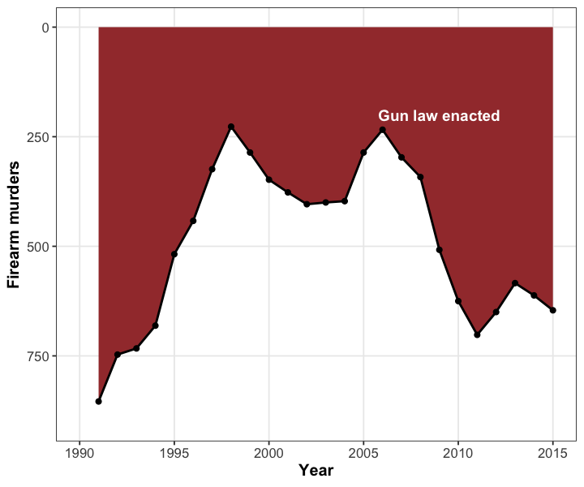

```r
# YOUR ANSWER HERE
library(readr)
library(dplyr)
library(ggplot2)

options(repr.plot.width = 6.0, repr.plot.height = 5.0)

guns <- read_csv("data/guns-r-us.csv", show_col_types = FALSE) %>%
  rename(
    year = `Year`,
    murders = `Firearm murders`
  )

ggplot(guns, aes(x = year, y = murders)) +
  geom_area(fill = "#a33a3a") +
  geom_line(color = "black", linewidth = 0.8) +
  geom_point(color = "black", size = 1.6) +
  annotate("text",
           x = 2009, y = 200,
           label = "Gun law enacted",
           color = "white", size = 4, fontface = "bold") +
  labs(x = "Year", y = "Firearm murders") +
  scale_x_continuous(limits = c(1990, 2015), breaks = seq(1990, 2015, 5)) +
  scale_y_reverse(limits = c(900, 0), breaks = c(0, 250, 500, 750)) +
  theme_bw() +
  theme(
    panel.grid.minor = element_blank(),
    axis.title = element_text(size = 12, face = "bold"),
    axis.text  = element_text(size = 10)
  )
```

### Question 3.3

rubric={viz:2}

#### R

Improve my ggplot plot. Chose the best type of plot to accurately reveal what the data looks like. Design the plot to be an effective plot for communication purposes, this includes proper figure size, axis/figure titles, font sizes, colors, etc.

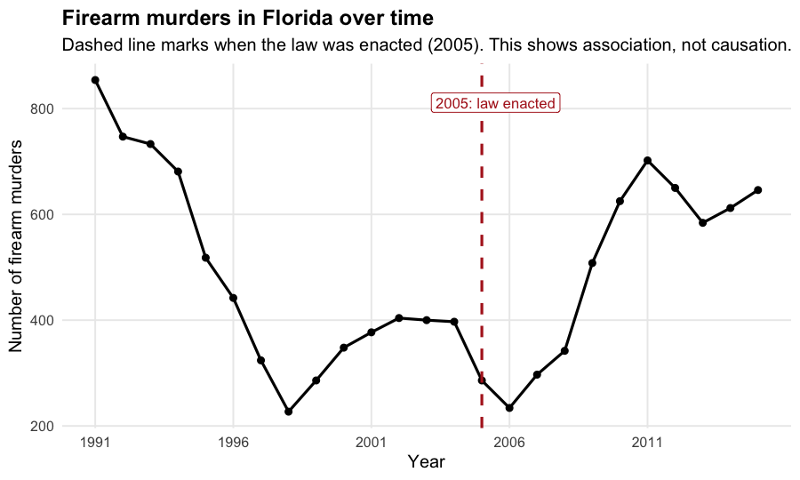

```r
# YOUR ANSWER HERE
library(readr)
library(dplyr)
library(ggplot2)

options(repr.plot.width = 7.5, repr.plot.height = 4.5)

guns <- read_csv("data/guns-r-us.csv", show_col_types = FALSE) %>%
  rename(
    year = `Year`,
    murders = `Firearm murders`
  )

law_year <- 2005

ggplot(guns, aes(x = year, y = murders)) +
  geom_line(linewidth = 0.9, color = "black") +
  geom_point(size = 1.8, color = "black") +
  geom_vline(xintercept = law_year, linetype = "dashed", linewidth = 0.9, color = "firebrick") +
  annotate(
    "label",
    x = law_year + 0.5,
    y = max(guns$murders) * 0.95,
    label = "2005: law enacted",
    size = 3.5,
    label.size = 0,
    fill = "white",
    color = "firebrick"
  ) +
  labs(
    title = "Firearm murders in Florida over time",
    subtitle = "Dashed line marks when the law was enacted (2005). This shows association, not causation.",
    x = "Year",
    y = "Number of firearm murders"
  ) +
  scale_x_continuous(breaks = seq(min(guns$year), max(guns$year), 5)) +
  theme_minimal(base_size = 12) +
  theme(
    plot.title = element_text(face = "bold"),
    panel.grid.minor = element_blank()
  )
```

# My approval ratings are astronomical

## The data

The (fictional) `state-comparison.csv` dataset contains a sample of voters from my state and a neighboring state of similar socioeconomic standard. Voters in each state were asked to rate their approval of the state's mayor on a scale from 0 - 10,000.

## My claim

My approval ratings are through the roof! I am clearly doing a better job than my colleague and competitor next doors. And as you can see we sampled enough people to get smooth curves, which means that this difference is both likely to be statistically significant and the magnitude is just too big to ignore. There seems to be a few bores on the lower end of the spectrum, but can't win them all I guess. Do you want a 10k approval rating future?

### Question 4.1

rubric={reasoning:2,writing:1}

- Explain which mistakes (if any) I have done in my plot and provide an interpretation of the data that is more correct than mine. Be brief and clear in your answer.
- You might have some ideas just from looking at my plot, but you will likely need to do some investigation yourself to answer this question fully. You can reference your improved plot as needed.

This plot is misleading because the KDE “waves” hide the raw data and sample size, so the smooth curves do not prove that the difference is real or statistically significant. Also, using filled overlapping densities makes comparison harder and can exaggerate the separation. Finally, the 0–10,000 scale and the vague x-axis label (“the value”) reduce interpretability.

A more accurate interpretation is that the two states’ approval distributions overlap a lot: one state appears to have more very high ratings, but many voters in both states give similar ratings. To support the claim, we would need to show the number of voters and add clearer summaries/uncertainty (e.g., median/IQR, confidence bands, or raw points).

### Question 4.2

rubric={accuracy:2}

#### R

Recreate my ggplot version of the plot. Your plot should look as close as possible to mine in the image above.

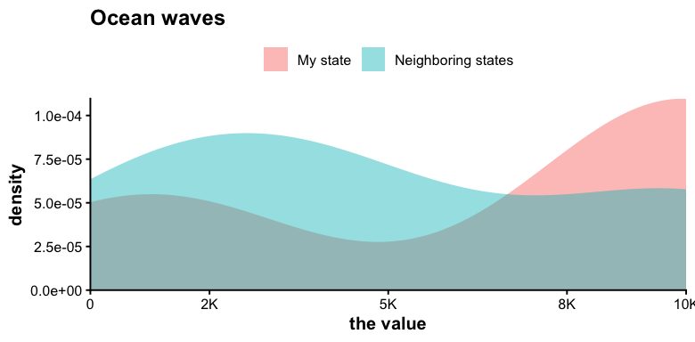

```r
# YOUR ANSWER HERE
library(readr)
library(ggplot2)
library(dplyr)

options(repr.plot.width = 6.5, repr.plot.height = 3.2)

df <- read_csv("data/state-comparison.csv", show_col_types = FALSE)

ggplot(df, aes(x = `the value`, fill = where)) +
  geom_density(alpha = 0.45, color = NA) +
  labs(
    title = "Ocean waves",
    x = "the value",
    y = "density",
    fill = NULL
  ) +
  scale_x_continuous(
    limits = c(0, 10000),
    breaks = c(0, 2000, 5000, 8000, 10000),
    labels = c("0", "2K", "5K", "8K", "10K"),
    expand = c(0, 0)
  ) +
  scale_y_continuous(expand = c(0, 0)) +
  coord_cartesian(ylim = c(0, NA), expand = FALSE) +
  theme_classic(base_size = 12) +
  theme(
    legend.position = "top",
    plot.title = element_text(face = "bold"),
    axis.title = element_text(face = "bold")
  )
```

### Question 4.3 (Optional)

rubric={viz:1}

#### R

Improve my ggplot plot. Chose the best type of plot to accurately reveal what the data looks like. Design the plot to be an effective plot for communication purposes, this includes proper figure size, axis/figure titles, font sizes, colors, etc.

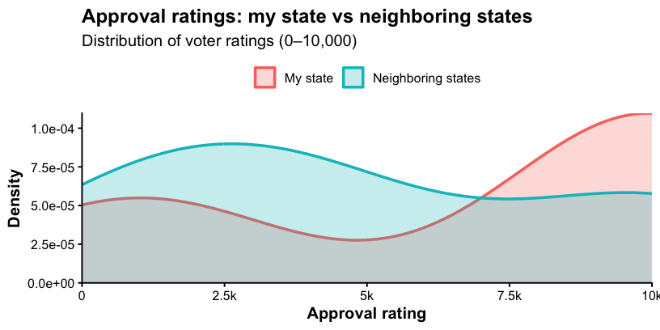

```r
# YOUR ANSWER HERE
library(readr)
library(ggplot2)
library(dplyr)

options(repr.plot.width = 6.8, repr.plot.height = 3.4)

df <- read_csv("data/state-comparison.csv", show_col_types = FALSE)

ggplot(df, aes(x = `the value`, color = where, fill = where)) +
  geom_density(alpha = 0.25, linewidth = 1) +
  labs(
    title = "Approval ratings: my state vs neighboring states",
    subtitle = "Distribution of voter ratings (0–10,000)",
    x = "Approval rating",
    y = "Density",
    color = NULL,
    fill = NULL
  ) +
  scale_x_continuous(
    limits = c(0, 10000),
    breaks = c(0, 2500, 5000, 7500, 10000),
    labels = c("0", "2.5k", "5k", "7.5k", "10k"),
    expand = c(0, 0)
  ) +
  scale_y_continuous(expand = c(0, 0)) +
  theme_classic(base_size = 12) +
  theme(
    legend.position = "top",
    plot.title = element_text(face = "bold"),
    axis.title = element_text(face = "bold")
  )
```

### Question 5 (Optional)

rubric={viz:0.5,reasoning:0.5}

#### R or Python

Pick a existing ggplot or Altair chart and improve at least 3 different communication related aspects of this plot that we have discussed in lectures. In addition, show your proficiency in reading the documentation and looking for help online, by finding one communication related parameter that we have not discussed in lectures and use it to improve the visuals of the plot (it is also ok to use an option that we haven’t discussed of a parameter that we have discussed).

1. Paste in the code of the existing plot you picked and run it so that we can see what the original looked like. Include the URL to the original plot as a comment in the code cell.
   - You can take any plot you want! As long as you can find the source code and paste it here (and it is not copyright protected). There are suggestions for [ggplot here](https://www.r-graph-gallery.com/) and [Altair here](https://altair-viz.github.io/gallery/index.html).
2. In a new cell, make your modifications and plot the improved chart.
3. Briefly describe the changes you made and why they make this plot more suitable for communication. Explicitly mention which new parameter/option you picked that we have not discussed before and why you picked it.

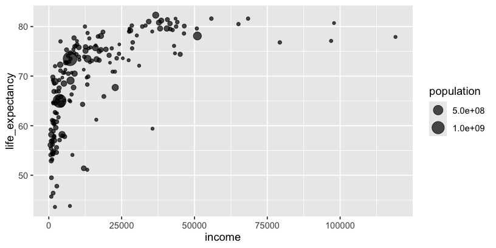

```r
# YOUR ANSWER TO #1 GOES HERE, REMEMBER THE URL.
# Source (idea adapted from r-graph-gallery bubble plot examples):
# https://www.r-graph-gallery.com/bubble-plot.html

library(readr)
library(dplyr)
library(ggplot2)

url <- "https://raw.githubusercontent.com/UofTCoders/workshops-dc-py/master/data/processed/world-data-gapminder.csv"
gap <- read_csv(url, show_col_types = FALSE)

df_2007 <- gap %>% filter(year == 2007)

ggplot(df_2007, aes(x = income, y = life_expectancy, size = population)) +
  geom_point(alpha = 0.7)
```

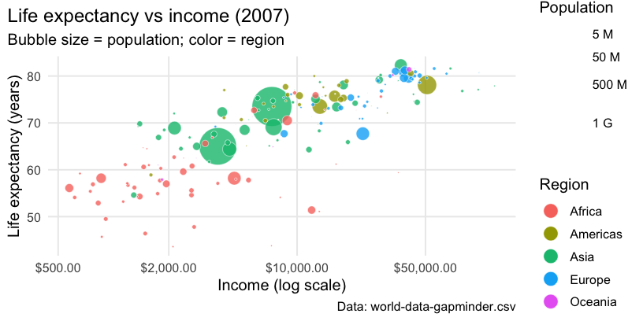

```r
# YOUR ANSWER TO #2 GOES HERE
library(readr)
library(dplyr)
library(ggplot2)
library(scales)

url <- "https://raw.githubusercontent.com/UofTCoders/workshops-dc-py/master/data/processed/world-data-gapminder.csv"
gap <- read_csv(url, show_col_types = FALSE)

df_2007 <- gap %>%
  filter(year == 2007) %>%
  arrange(desc(population))

ggplot(df_2007, aes(x = income, y = life_expectancy, size = population, fill = region)) +
  geom_point(shape = 21, color = "white", alpha = 0.80, stroke = 0.25) +
  scale_x_log10(
    labels = dollar_format(prefix = "$"),
    breaks = c(500, 2000, 10000, 50000)
  ) +
  scale_size_area(
    max_size = 14,
    breaks = c(5e6, 5e7, 5e8, 1e9),
    labels = label_number(scale_cut = cut_si(""))
  ) +
  labs(
    title = "Life expectancy vs income (2007)",
    subtitle = "Bubble size = population; color = region",
    x = "Income (log scale)",
    y = "Life expectancy (years)",
    fill = "Region",
    size = "Population",
    caption = "Data: world-data-gapminder.csv"
  ) +
  guides(
    # NEW parameter: make legend symbols easier to read
    size = guide_legend(override.aes = list(alpha = 1)),
    fill = guide_legend(override.aes = list(alpha = 1, size = 5))
  ) +
  theme_minimal(base_size = 12) +
  theme(
    plot.title.position = "plot",
    panel.grid.minor = element_blank(),
    legend.position = "right"
  )
```

Ready to submit? I hope you had a favorable view of my data interpretations or there might be trouble coming your way in lab4...

# Submission to Canvas

When you are ready to submit your assignment do the following:

1. Run all cells in your notebook to make sure there are no errors by doing `Kernel -> Restart Kernel and Run All Cells...`
2. Commit and push all your work (including the .ipynb file) to GitHub.
3. Submit a link to your repo on Canvas (this has to be done only once per group).